# Shanaa - Problem Set #1

## 1. Monty Hall problem

Set up: There is a car behind 1 of 3 closed doors, while the other 2 contain goats. We pick one of the three doors. Monty, a gameshow host, then opens one of the two other doors to reveal a goat. We must decide, given this new evidence of a goat being behind another door, whether to stay with our original choice, or to switch our choice to the remaining door. We win if the door we choose has a car behind it.

We can use conditional probability and Bayes Theorem to make an informed decision on whether to stay or switch.

Let C be the event where a car is behind the door we chose. P(C) = 1/3.  
Let M be the event where Monty reveals a goat behind another door.  
We must figure out the **probability of a car being behind the door we chose, given Monty reveals a goat behind another door**. That is, P(C|M).

Bayes Therom tells us the following:
$$P(C|M) = \frac{P(M|C) P(C)}{P(M)}$$
We know that P(C), the prior probaility, = 1/3.
P(M|C) is the probability that Monty reveals a goat behind another door, given that a car is behind the door we chose. Monty will **always** reveal a goat behind another door, so P(M|C), the likelihood, = 1.
P(M) is the probability that Monty reveals a goat behind another door. This also always occurs (that is, P(M) = 1), but we can illustrate this using the law of partition.

Using the law of total probaility, since C and notC partition Ω, we get the following:
$$P(M) = P(M|C)P(C) + P(M|notC)P(notC)$$
We have already determined P(M|C) = 1, and P(C) = 1/3.
P(notC) is the probability that a car is **not** behind the door we chose. P(notC) = 1 - P(C) = 2/3.
P(M|notC) is the probability that Monty reveals a goat behind another door, given that a car is **not** behind the door we chose. Again, Monty will **always** reveal a goat behind another door, so P(M|notC) = 1.

If we plug in our numbers, we get:
$$P(M) = 1*\frac{1}{3} + 1*\frac{2}{3} = 1$$

Now we can solve for our conditional probability:
$$P(C|M) = \frac{1* \frac{1}{3}}{1} = \frac{1}{3}$$
We see that our posterior probability is the same as our prior probability. Given that Monty reveals a goat behind another door, the probability of a car being behind door we chose is still 1/3.

Since we know that the probablity of a car **not** being behind the door we chose, i.e. P(notC), is 2/3 (again, 1 - P(C)), and there is only other door left, the probability of a car being behind the remaining door is 2/3.

Therefore, when Monty reveals a goat behind a door we did not choose, if we want to have the highest probability of choosing the door with the car, we should always switch our choice to the remaining door.

## 2. rcnorm function

```r
# rcnorm function
rcnorm <- function(nsamp, mean = 0, sd = 1, nclip = 2) {
  # create an empty vector with a length of nsamp
  dist <- vector("numeric", nsamp)

  # repeat for every index of dist
  for (i in seq_along(dist)){

    # to each index in dist: assign a number from a normal distribution with the gived mean and sd
    dist[i] <- rnorm(n = 1, mean = mean, sd = sd)

    # keep resampling the value at index i if it does not fall within nclip standard deviations from the mean
    while (dist[i] < (mean - sd * nclip) || dist[i] > (mean + sd * nclip))
        dist[i] <- rnorm(n = 1, mean = mean, sd = sd)
  }

  # return dist
  return(dist)
}
```

## 3. Keeling data

### a) Read the Keeling data as a dataframe

```r
keelingData <- read.table("problem set 1/keeling.txt", header = TRUE, sep = ",")
# removing negative numbers from co2_fit
keelingData[keelingData$co2_fit < 0, "co2_fit"] <- NaN
```

### b) Plotting the CO2 concentration (co2_fit column) for each month

Note: mapped the months to colours to illustrate the trend there

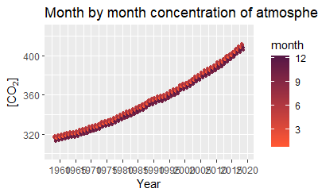

```r
# load the ggplot2 library (for plotting)
library(ggplot2)
plot <- ggplot(keelingData, aes(date_float, co2_fit)) +
  geom_point(aes(color = month), size = 1) +
  scale_x_continuous(name="Year", breaks = seq(1950, 2020, 5)) +
  scale_y_continuous(name=expression("[CO"["2"]*"]"), limits = c(300, 425)) +
  scale_color_gradient(low = "#FF5733", high = "#581845") +
  ggtitle("Month by month concentration of atmospheric carbon dioxide")
plot
```

### c) Plotting the averate CO2 concentration for each year

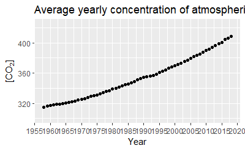

```r
# create list of unique years
years <- unique(keelingData$year)
# create empty vector for yearly means
yearlyMeans <- vector("numeric", length(years))
# loop over unique values in year and add means to yearlyMeans list
for (i in seq_along(yearlyMeans)){
  yearlyMeans[i] = mean(keelingData[keelingData$year == years[i], "co2_fit"], na.rm = TRUE)
}
# create yearly means dataframe
yearlyMeansDF <- data.frame(year = years, co2_fit_avg = yearlyMeans)
# plot the data
plot <- ggplot(yearlyMeansDF, aes(year, co2_fit_avg)) +
  geom_point() +
  scale_x_continuous(name="Year", breaks = seq(1950, 2020, 5)) +
  scale_y_continuous(name=expression("[CO"["2"]*"]"), limits = c(300, 425)) +
  ggtitle("Average yearly concentration of atmospheric carbon dioxide")
plot
```

### d) Plotting the averate CO2 concentration for each month

Note: mapped the months to the same colours as in part b to highlight the relationship between the two plots

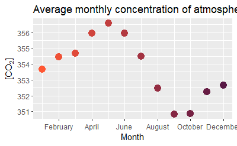

```r
# create list of unique months
months <- unique(keelingData$month)
# create empty vector for monthly means
monthlyMeans <- vector("numeric", length(months))
# loop over unique values in month and add means to monthlyMeans list
for (i in seq_along(monthlyMeans)){
  monthlyMeans[i] = mean(keelingData[keelingData$month == months[i], "co2_fit"], na.rm = TRUE)
}
# create monthly means dataframe
monthlyMeansDF <- data.frame(month = months, co2_fit_avg = monthlyMeans)
# plot the data
plot <- ggplot(monthlyMeansDF, aes(month, co2_fit_avg)) +
  geom_point(aes(color = month), size = 4) +
  scale_x_continuous(name="Month", breaks = seq(0,12,2), labels = c("", "February", "April", "June", "August", "October", "December")) +
  scale_y_continuous(name=expression("[CO"["2"]*"]")) +
  scale_color_gradient(low = "#FF5733", high = "#581845") +
  theme(legend.position = "none") +
  ggtitle("Average monthly concentration of atmospheric carbon dioxide")
plot
```